# ggplot2 Elegant Graphics for Data Analysis

홍우헌

quasar103@naver.com

2018-06-21

> Chapter 3  
> Toolbox

레이어의 세가지 목적

- To display the data. We plot the raw data for many reasons, relying on our skills at pattern detection to spot gross structure, local structure, and outliers.In the earliest stages of data exploration, it is often the only layer.
- To display a statistical summary of the data. As we develop and explore models of the data, it is useful to display model predictions in the context of the data. Showing the data helps us improve the model, and showing the model helps reveal subtleties of the data that we might otherwise miss
- To add additional metadata: context, annotations, and references. A metadata layer displays background context, annotations that help to give meaning to the raw data, or fixed references that aid comparisons across panels. Metadata can be useful in the background and foreground. A map is often used as a background layer with spatial data. Background metadata should be rendered so that it doesn’t interfere with your perception of the data, so is usually displayed underneath the data and formatted so that it is minimally perceptible. That is, if you concentrate on it, you can see it with ease, but it doesn’t jump out at you when you are casually browsing the plot.

# 1 Basic Plot Types

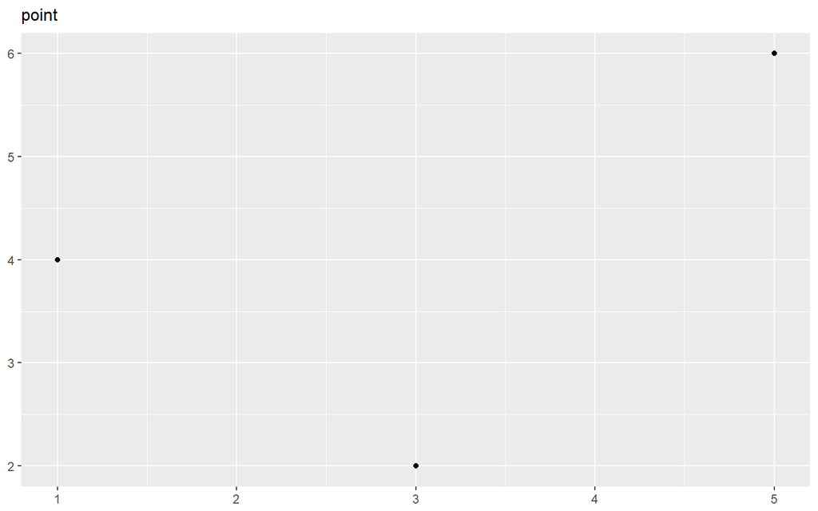

```r
df <- data.frame(
x = c(3, 1, 5),
y = c(2, 4, 6),
label = c("a","b","c")
)
p <- ggplot(df, aes(x, y, label = label)) +
labs(x = NULL, y = NULL) + # Hide axis label
theme(plot.title = element_text(size = 12)) # Shrink plot title
p + geom_point() + ggtitle("point")
```

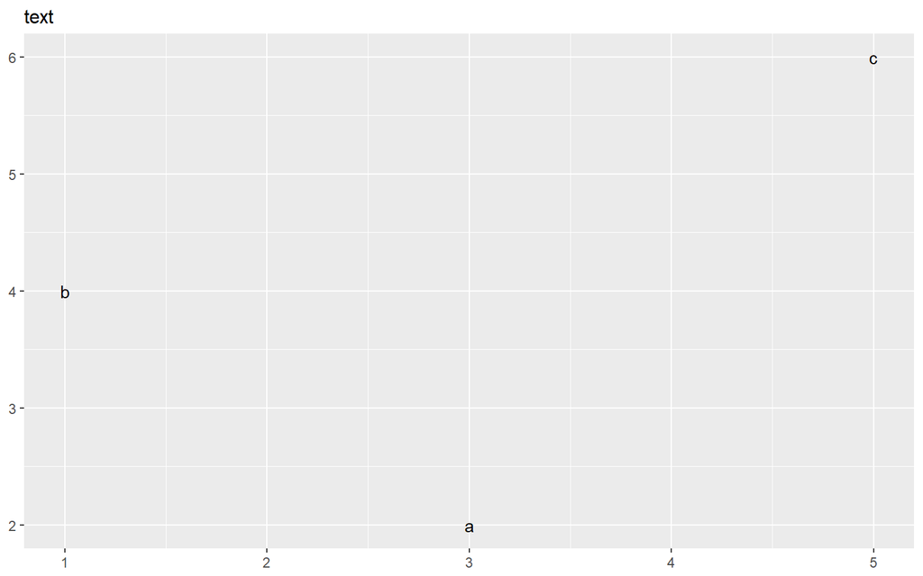

```r
p + geom_text() + ggtitle("text")
```

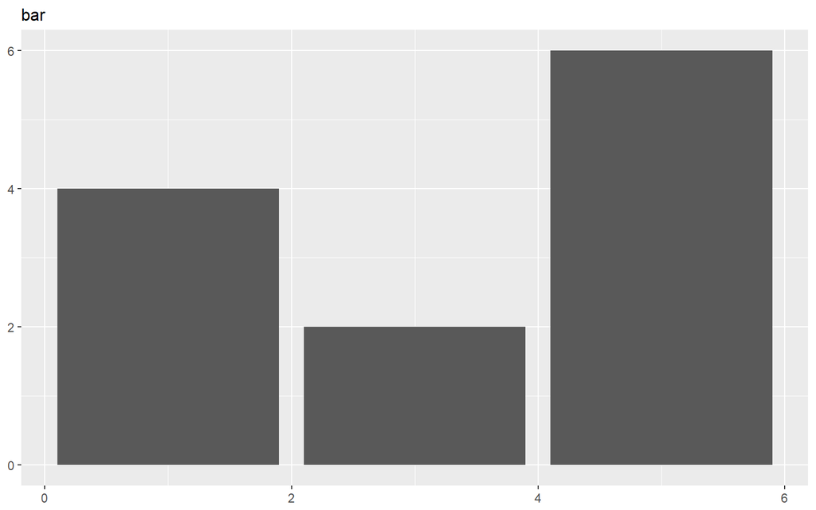

```r
p + geom_bar(stat = "identity") + ggtitle("bar")
```

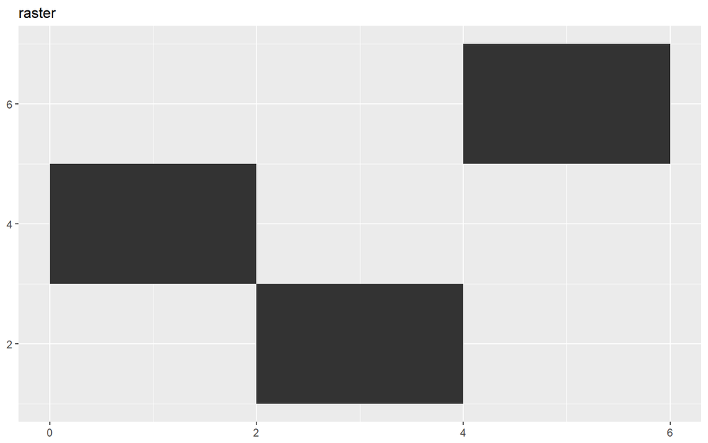

```r
p + geom_tile() + ggtitle("raster")
```

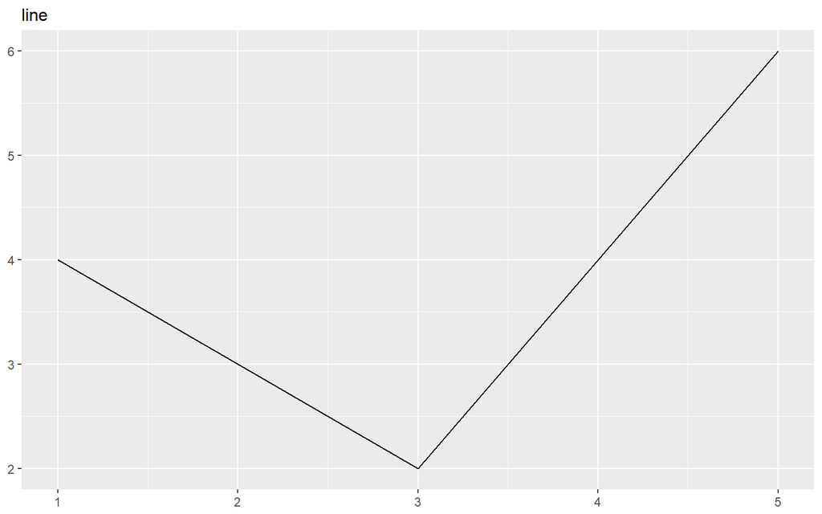

```r
p + geom_line() + ggtitle("line")
```

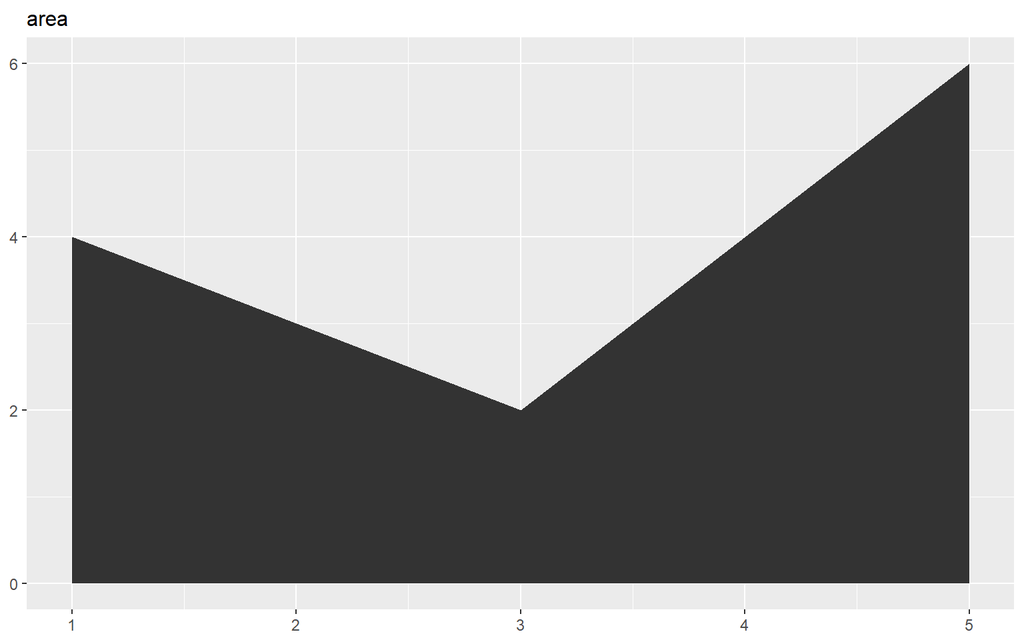

```r
p + geom_area() + ggtitle("area")
```

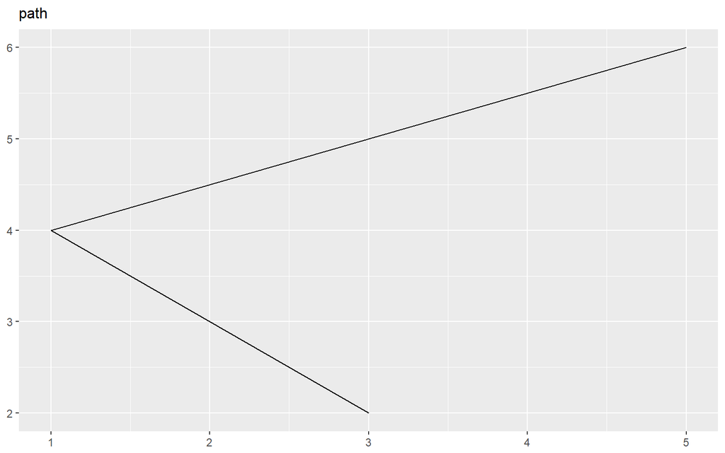

```r
p + geom_path() + ggtitle("path")
```

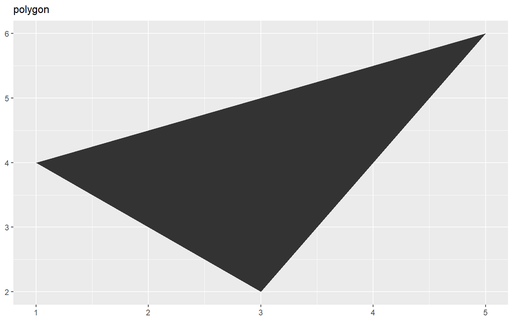

```r
p + geom_polygon() + ggtitle("polygon")
```

geom_path() 와 geom_polygon() 의 차이 : path가 지나간 길의 내부를 색칠 geom_path() 와 geom_line()의 차이 : line은 x가 작은것부터 큰것까지 선을 그리는 반면 path는 데이터 x의 순서대로 그린다.

# 2 Labels

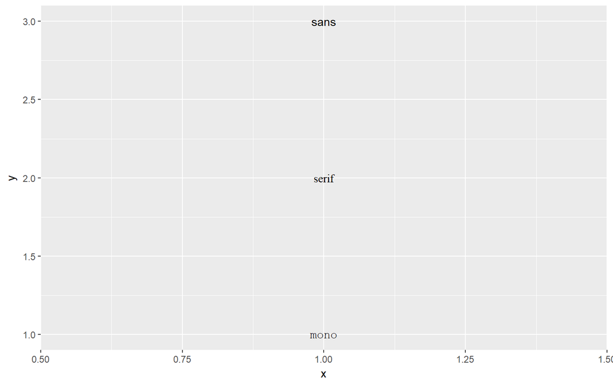

```r
df <- data.frame(x = 1, y = 3:1, family = c("sans", "serif", "mono"))
ggplot(df, aes(x, y)) +
  geom_text(aes(label = family, family = family)) #family는 글꼴을 의미한다.
```

폰트 패키지

- **showtext**, https://github.com/yixuan/showtext, by Yixuan Qiu, makes GD-independent plots by rendering all text as polygons.
- extrafont, https://github.com/wch/extrafont, by Winston Chang, converts fonts to a standard format that all devices can use.

```r
library(showtext)
```

```r
## Loading Google fonts (http://www.google.com/fonts)
font_add_google("Gochi Hand", "gochi")
font_add_google("Schoolbell", "bell")
font_add_google("Covered By Your Grace", "grace")
font_add_google("Rock Salt", "rock")
## Automatically use showtext to render text for future devices
showtext_auto()
## Tell showtext the resolution of the device,
## only needed for bitmap graphics. Default is 96
## showtext_opts(dpi = 96)
```

주의 `library(cowplot)` 을 사용하면 기본 theme 설정이 바뀐다. `cowplot::`사용

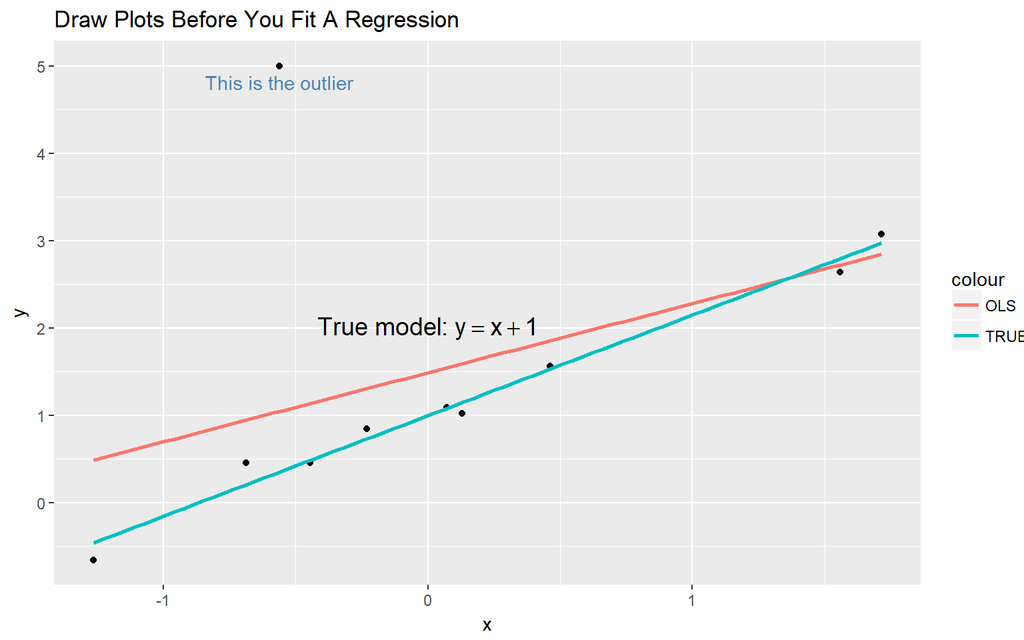

```r
set.seed(123)
x <- rnorm(10)
y <- 1 + x + rnorm(10, sd = 0.2)
y[1] <- 5
df <- data.frame(x =x , y = y)
mod <- lm(y ~ x, data = df)
std_resid <- MASS::stdres(mod)
outlier <- filter(df, abs(std_resid) > 2)

## Plotting functions as usual
## Open a graphics device if you want, e.g.
## png("demo.png", 700, 600, res = 96)

model_label <-  expression(paste("True model: ", y == x + 1))

ggplot(df, aes(x, y)) +
  geom_point() +
  geom_smooth(method = "lm", se = FALSE, aes(colour = "OLS")) +
  geom_text(data = outlier, aes(label = "This is the outlier"), family = "grace", colour = "steelblue", vjust = "top", nudge_y = -0.1) +
  geom_smooth(data = df[!(df$x %in% outlier$x), ], aes(x, y, colour = "TRUE"), method = "lm", se = FALSE) +
  ggtitle("Draw Plots Before You Fit A Regression") +
  theme(plot.title = element_text(family = "bell")) +
  cowplot::draw_label(model_label, x = 0, y = 2, fontfamily = "rock")
```

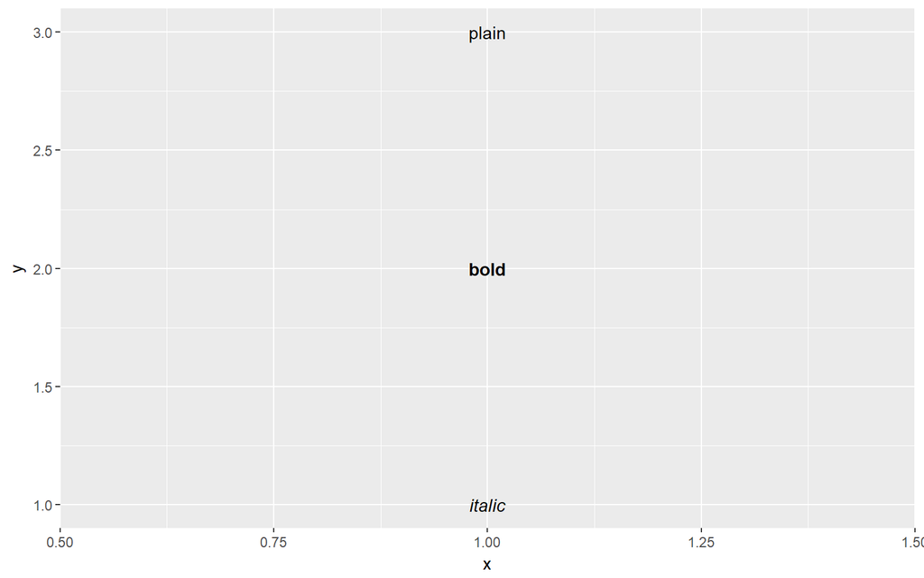

```r
df <- data.frame(x = 1, y = 3:1, face = c("plain", "bold", "italic"))
ggplot(df, aes(x, y)) +
  geom_text(aes(label = face, fontface = face))
```

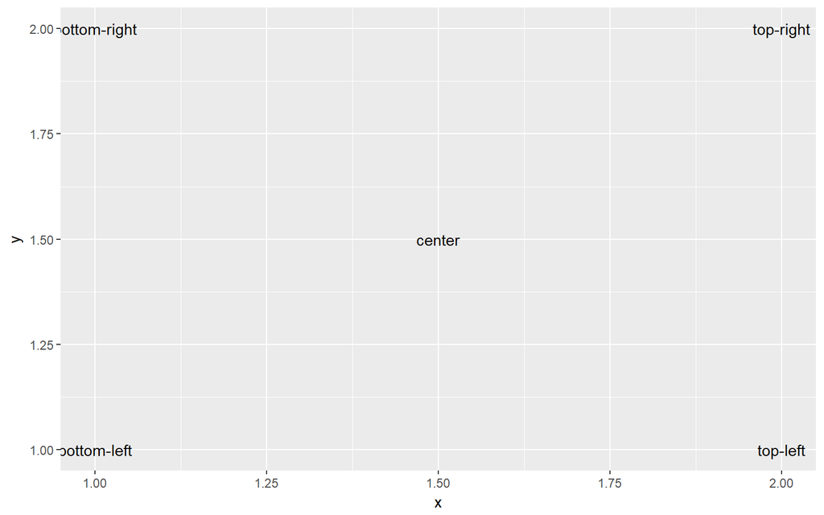

```r
df <- data.frame(
  x = c(1, 1, 2, 2, 1.5),
  y = c(1, 2, 1, 2, 1.5),
  text = c(
    "bottom-left", "bottom-right",
    "top-left", "top-right", "center"
  )
)
ggplot(df, aes(x, y)) +
  geom_text(aes(label = text))
```

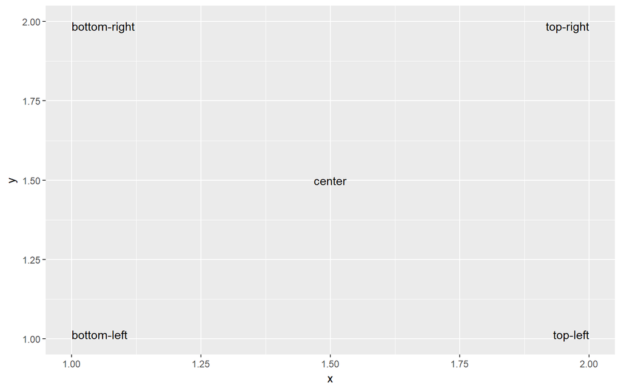

```r
ggplot(df, aes(x, y)) +
  geom_text(aes(label = text), vjust = "inward", hjust = "inward")
```

```r
#"inward"는 기억하자.
```

One of the most useful alignments is “inward” : it aligns text towards the middle of the plot 이 외에도 size(단위는 mm)와 angle을 조정할 수 있다.

The nudge x and nudge y parameters allow you to nudge the text a little horizontally or vertically

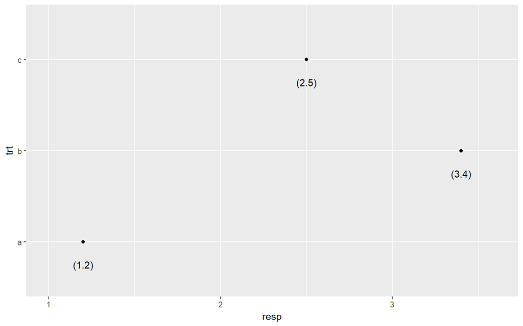

```r
df <- data.frame(trt = c("a", "b", "c"), resp = c(1.2, 3.4, 2.5))
ggplot(df, aes(resp, trt)) +
  geom_point() +
  geom_text(aes(label = paste0("(", resp, ")")), nudge_y = -0.25) +
  xlim(1, 3.6)
```

텍스트가 겹치면 check_overlap = TRUE 기억만 해두자.

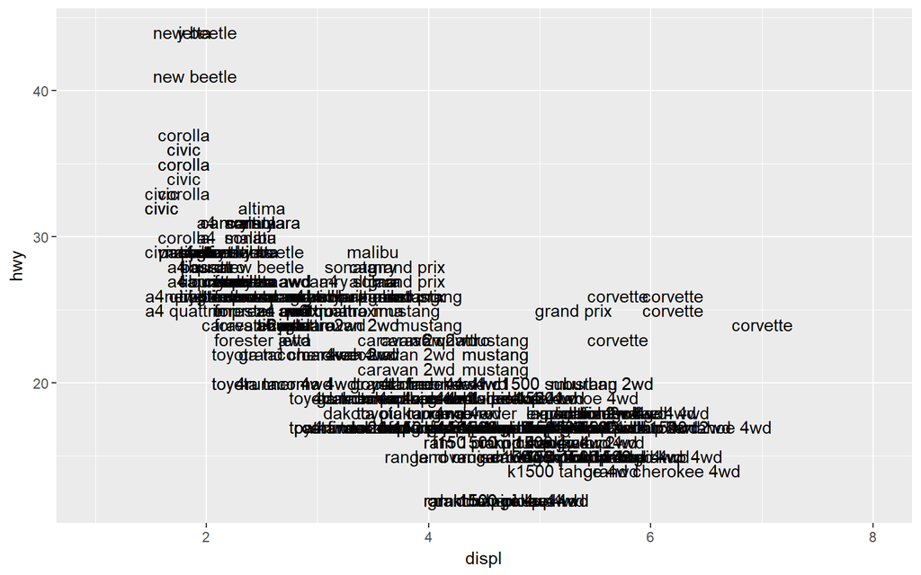

```r
ggplot(mpg, aes(displ, hwy)) +
  geom_text(aes(label = model)) +
  xlim(1, 8)
```

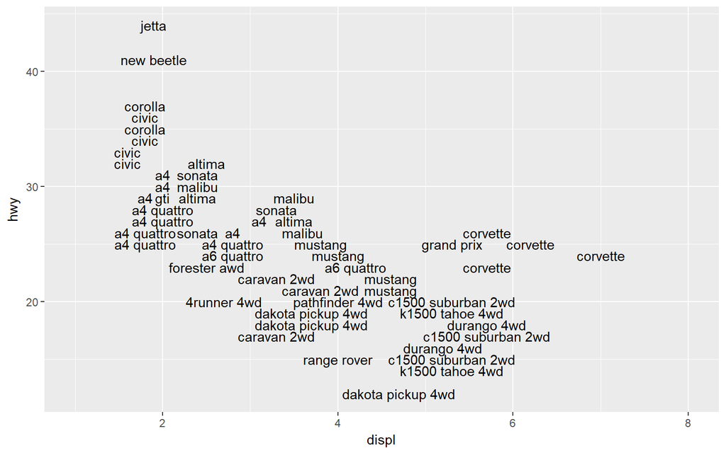

```r
ggplot(mpg, aes(displ, hwy)) +
  geom_text(aes(label = model), check_overlap = TRUE) +
  xlim(1, 8)
```

## 2.1 ggrepel 패키지

여기서 padding 옵션은 text나 label 주변을 둘러싸고 있는 공간을 의미한다.

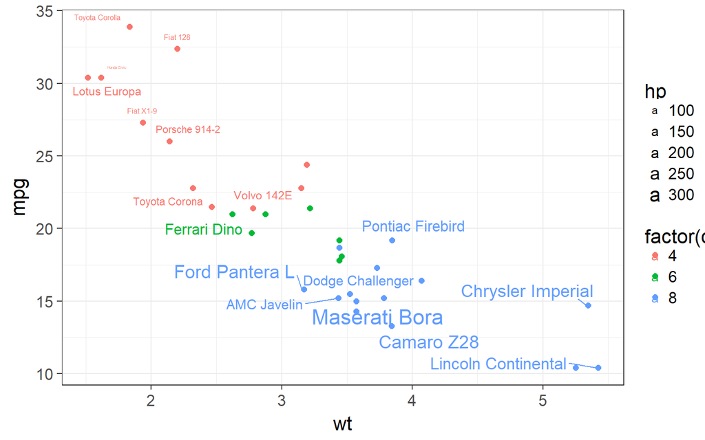

```r
mtcars$label <- rownames(mtcars)
mtcars$label[1:15] <- ""

library(ggrepel)
ggplot(mtcars, aes(wt, mpg)) +
  geom_point(aes(color = factor(cyl)), size = 2) +
  geom_text_repel(
    aes(
      color = factor(cyl), #텍스트의 색을 조정
      size = hp, # 텍스트의 사이즈를 조정할 수 있다.
      label = label
    ),
    point.padding = 0.25,
    box.padding = 0.25,
    nudge_y = 0.1
  ) +
  theme_bw(base_size = 16)
```

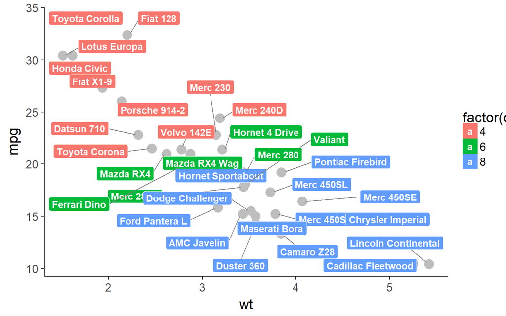

```r
ggplot(mtcars) +
  geom_point(aes(wt, mpg), size = 5, color = 'grey') +
  geom_label_repel(
    aes(wt, mpg, fill = factor(cyl), label = rownames(mtcars)),
    fontface = 'bold', color = 'white',
    box.padding = 0.35, point.padding = 0.5,
    segment.color = 'grey50' # 선색깔 지정가능
  ) +
  theme_classic(base_size = 16)
```

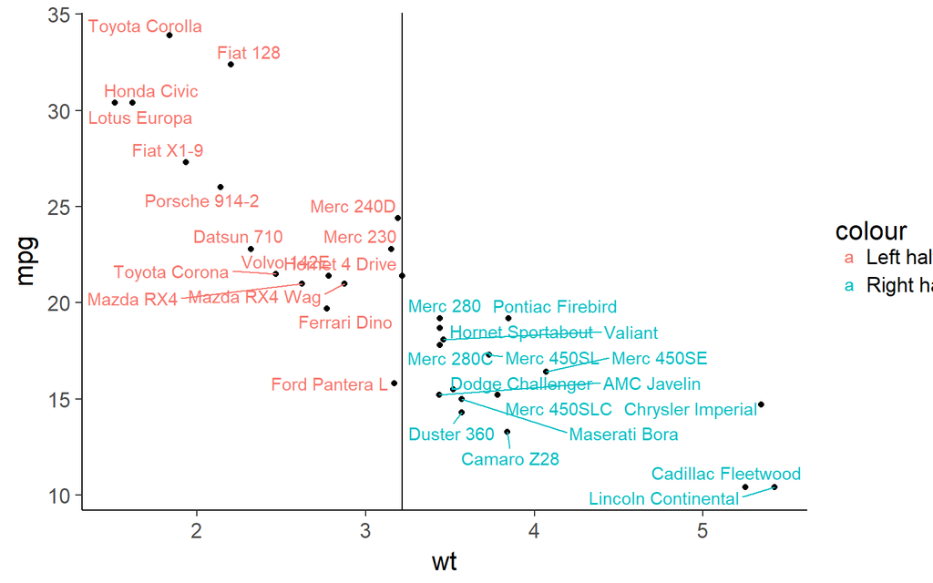

```r
set.seed(42)
data <- mtcars
mu <- mean(data$wt)

left <- data[data$wt < mu,]
right <- data[data$wt >= mu,]

ggplot() +
  geom_vline(xintercept = mu) +
  geom_point(
    data = data,
    mapping = aes(wt, mpg)
  ) +
  geom_text_repel(
    data = left,
    mapping = aes(wt, mpg, label = rownames(left), colour = 'Left half'),
    # Limit labels to the left of the vertical x=mu line
    xlim = c(NA, mu)
  ) +
  geom_text_repel(
    data = right,
    mapping = aes(wt, mpg, label = rownames(right), colour = 'Right half'),
    # Limit labels to the right of the vertical x=mu line
    xlim = c(mu, NA)
  ) +
  theme_classic(base_size = 16)
```

directlabels 패키지를 이용해 라인위에 글자를 적을 수 있지만 난 이 코드가 좀 더 마음에 든다. 기억해 두자.

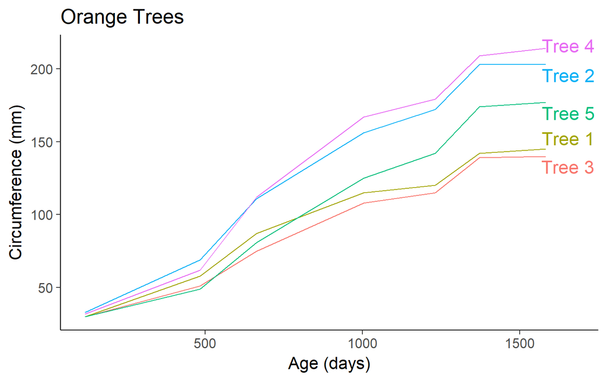

```r
ggplot(Orange, aes(age, circumference, color = Tree)) +
  geom_line() +
 coord_cartesian(xlim = c(min(Orange$age), max(Orange$age) + 90)) + #coord_cartesian : 원하는 범위로 zoom-in
  geom_text_repel(
    data = subset(Orange, age == max(age)), #기억!
    aes(label = paste("Tree", Tree)), # 기억!
    size = 6,
    nudge_x = 45,
    segment.color = NA # 선 색깔 없애기
  ) +
  theme_classic(base_size = 16) +
  theme(legend.position = "none") +
  labs(title = "Orange Trees", x = "Age (days)", y = "Circumference (mm)")
```

**reference** : https://cran.r-project.org/web/packages/ggrepel/vignettes/ggrepel.html 에서 알고리즘과 예제 참고.

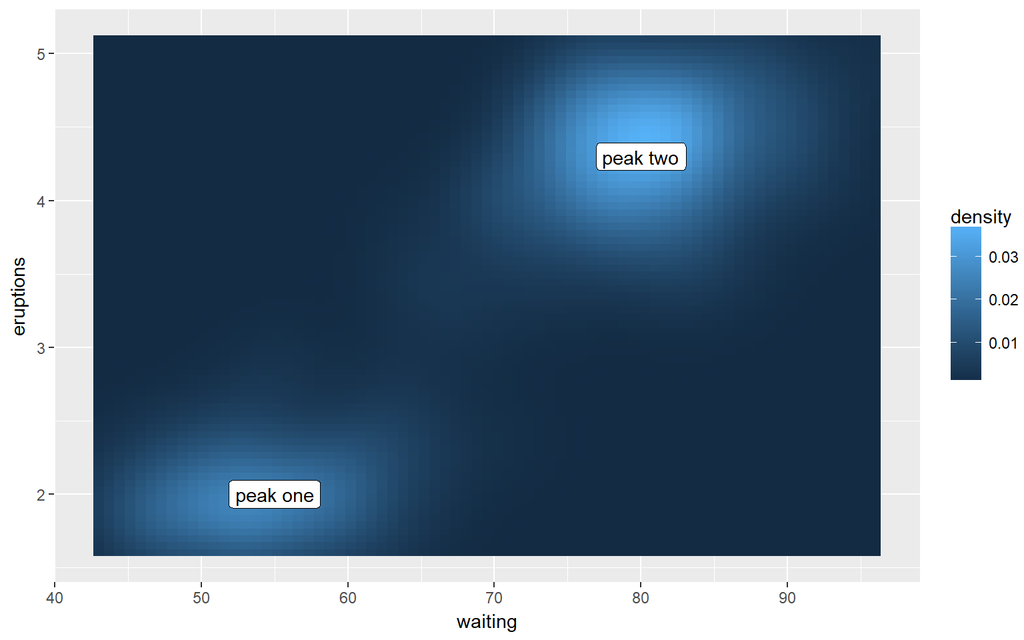

```r
label <- data.frame(
  waiting = c(55, 80),
  eruptions = c(2, 4.3),
  label = c("peak one", "peak two")
)
ggplot(faithfuld, aes(waiting, eruptions)) +
  geom_tile(aes(fill = density)) +
  geom_label(data = label, aes(label = label))
```

주의해야할 점

- Text does not affect the limits of the plot. 텍스트가 플랏 밖으로 나갈 수 있으므로 xlim과 ylim으로 플랏 사이즈를 조절하자.
- 레이블들이 겹치는 것을 주의하자.

# 3 Annotations

Annotations add metadata to your plot

- `geom_text()` outelier나 중요한 포인트에 라벨을 추가!
- `geom_rect()` 강조하고 싶은 플랏의 구역을 나타내고 싶을때 이용!
- `geom_line()`, `geom_path()`, and `geom_segment()` arrow인자를 이용해서 선의 방향을 나타내자!
- `geom_vlin()`, `geom_hline()` and `geom_abline()`을 이용해서 선을 넣어 강조하자!

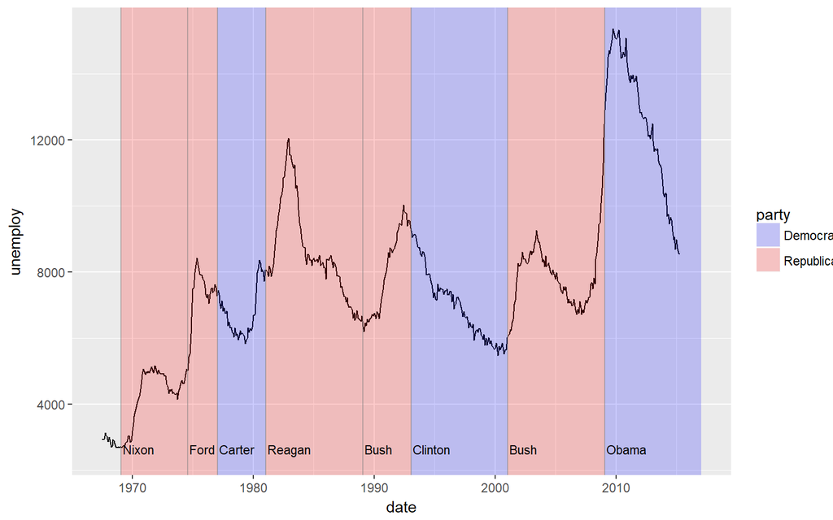

```r
presidential <- subset(presidential, start > economics$date[1])

ggplot(economics) +
  geom_line(aes(date, unemploy)) +
  geom_rect(data = presidential,
            aes(
              xmin = start, xmax = end, ymin = -Inf, ymax = Inf, fill = party), alpha = 0.2) +
  scale_fill_manual(values = c("blue", "red")) +
  geom_text(
    aes(x = start, y = 2500, label = name),
    data = presidential,
    size = 3, vjust = 0, hjust = 0, nudge_x = 50
  ) +
  geom_vline(data = presidential, aes(xintercept = as.numeric(start)), colour = "grey50", alpha = 0.5)
```

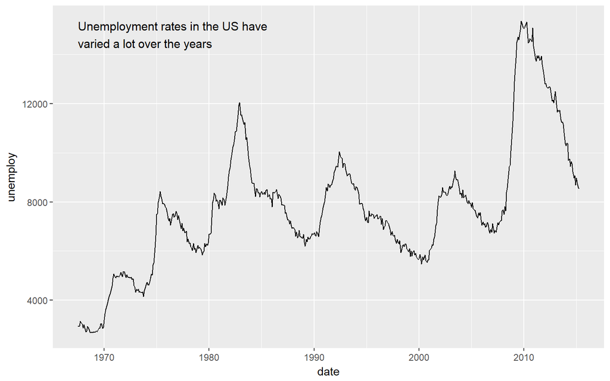

```r
yrng <- range(economics$unemploy)
xrng <- range(economics$date)
caption <- paste(strwrap("Unemployment rates in the US have
varied a lot over the years", 40), collapse = "\n")
ggplot(economics, aes(date, unemploy)) +
  geom_line() +
    annotate("text", x = xrng[1], y = yrng[2], label = caption,
    hjust = 0, vjust = 1, size = 4
)
```

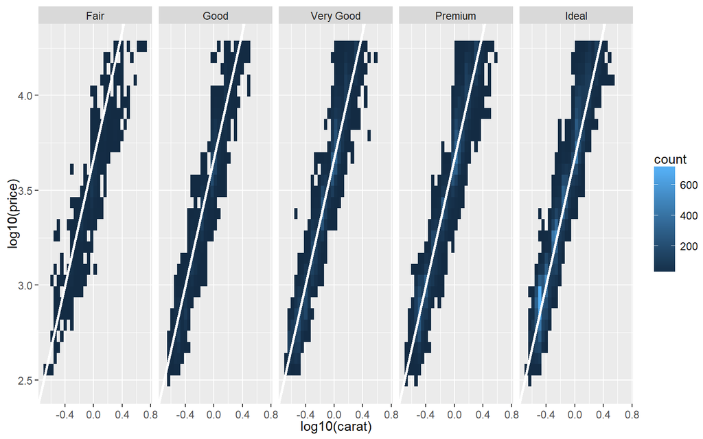

```r
mod_coef <- coef(lm(log10(price) ~ log10(carat), data = diamonds))
ggplot(diamonds, aes(log10(carat), log10(price))) +
  geom_bin2d() +
  geom_abline(intercept = mod_coef[1], slope = mod_coef[2],
    colour = "white", size = 1) +
  facet_wrap(~cut, nrow = 1)
```

```r
 # ggplot(diamonds, aes(log10(carat), log10(price))) +
 #   geom_bin2d() +
 #   geom_smooth(method = "lm", colour = "white", size = 1, se = FALSE) +
 #   facet_wrap(~cut, nrow = 1) +
 #  ylim(2.5, 4.3)
```

# 4 Collective Geoms

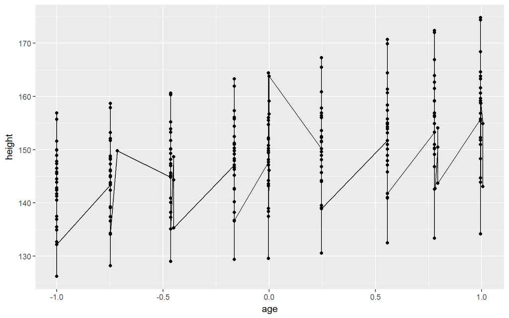

```r
data(Oxboys, package = "nlme") # 패키지 로드하지않고 패키지 내부 데이터만 로드
ggplot(Oxboys, aes(age, height)) +
  geom_point() +
  geom_line()
```

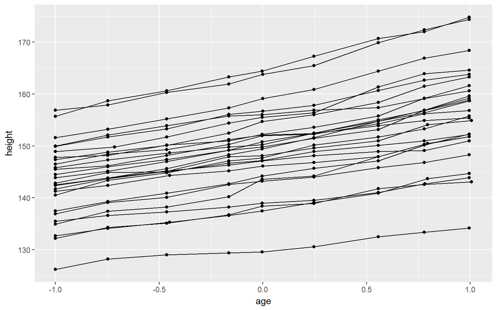

```r
ggplot(Oxboys, aes(age, height, group = Subject)) +
  geom_point() +
  geom_line()
```

그룹이 단일 변수에 의해 정의되지 않고 대신에 여러개의 변수의 조합에 의해 정의 되어 진다면 `interaction()` 을 이용하여라. e.g. `aes(group = interacton(school_id, student_id))`

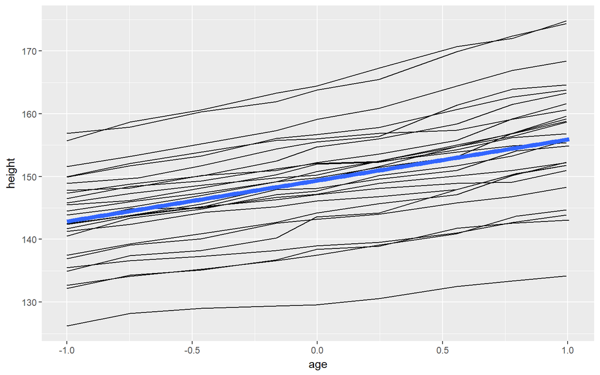

```r
ggplot(Oxboys, aes(age, height )) +
  geom_line(aes(group = Subject)) + #data layer에서 그룹을 지정해주면 회귀선이 너무 많이 그려짐
  geom_smooth(method = "lm", size = 2, se = FALSE)
```

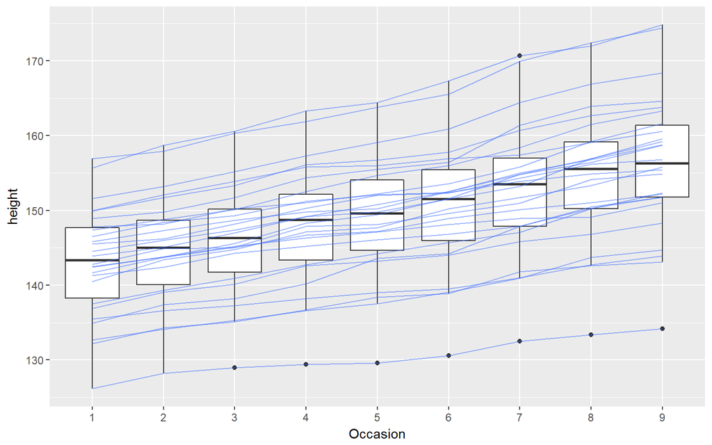

```r
ggplot(Oxboys, aes(Occasion, height)) +
  geom_boxplot() +
  geom_line(aes(group = Subject), colour = "#3366FF", alpha = 0.5)
```

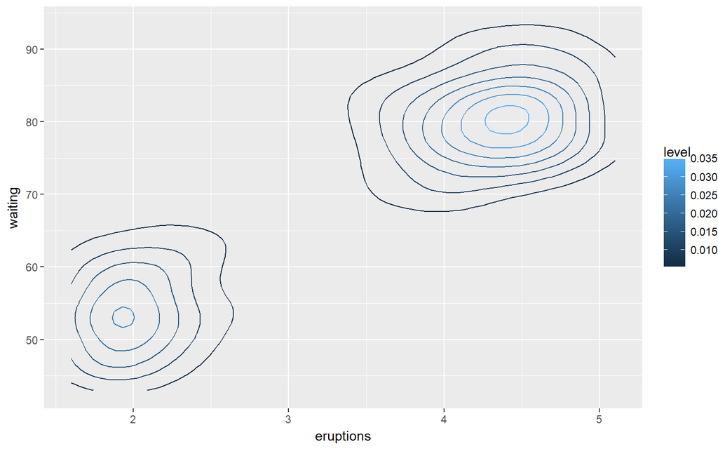

```r
ggplot(faithfuld, aes(eruptions, waiting)) +
  geom_contour(aes(z = density, colour = ..level..))
```

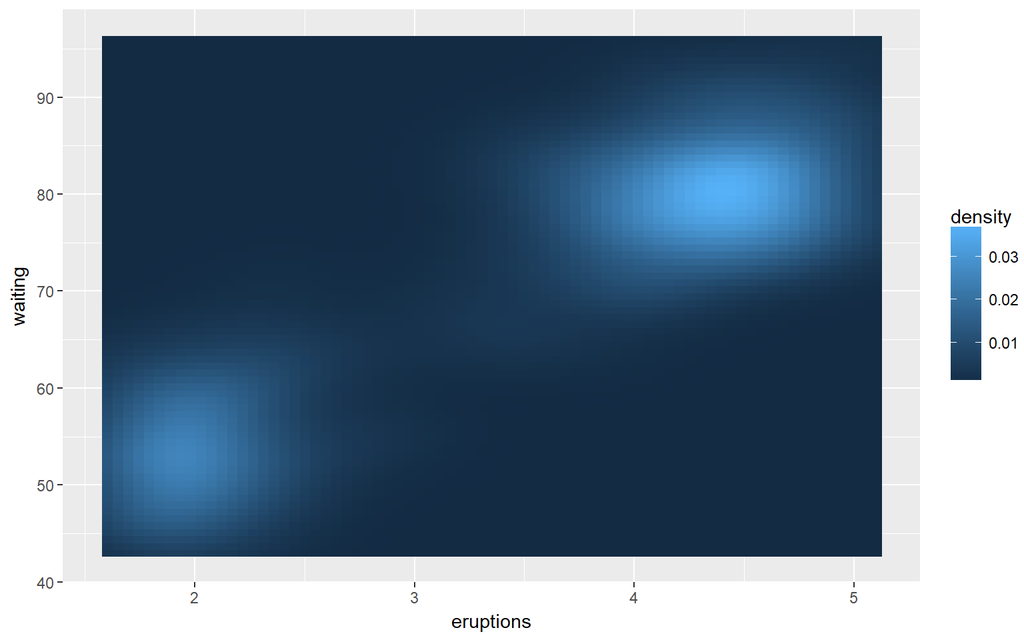

```r
ggplot(faithfuld, aes(eruptions, waiting)) +
  geom_raster(aes(fill = density))
```

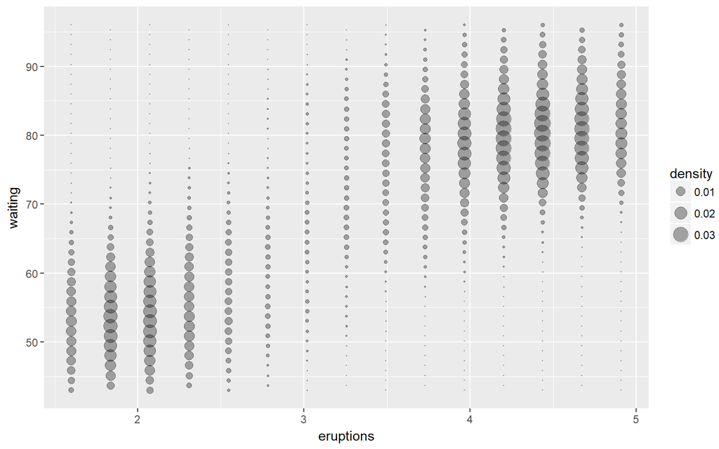

```r
# Bubble plots work better with fewer observations
small <- faithfuld[seq(1, nrow(faithfuld), by = 10), ] #정렬 되어 있으니까 계통추출로 뽑자.
ggplot(small, aes(eruptions, waiting)) +
  geom_point(aes(size = density), alpha = 1/3) +
  scale_size_area()
```

Lines and paths operate on an off-by-one principle: This means that the aesthetic for the last observation is not used:

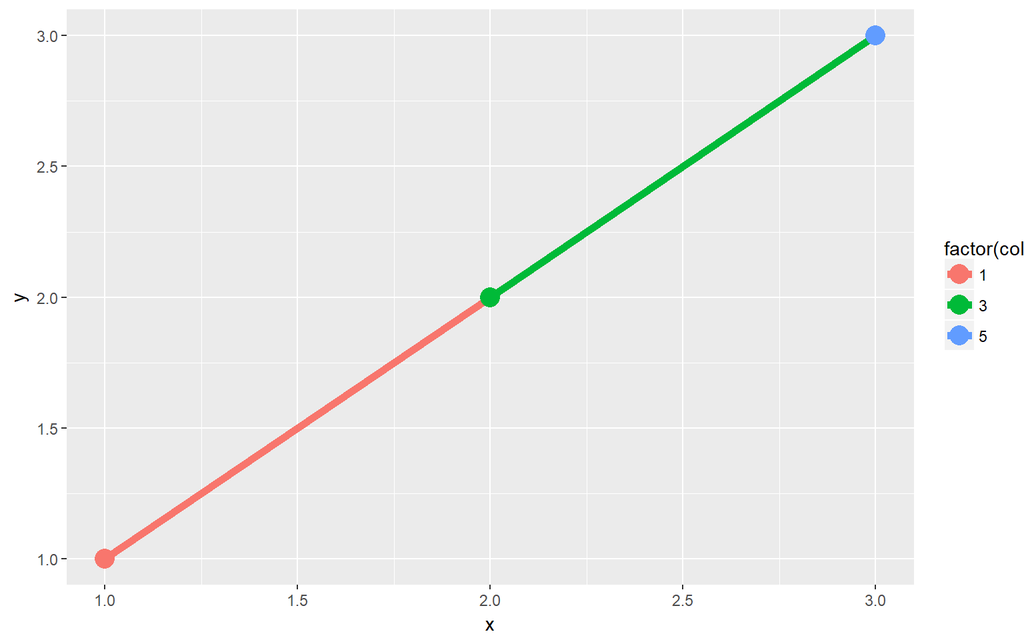

```r
df <- data.frame(x = 1:3, y = 1:3, colour = c(1,3,5))
ggplot(df, aes(x, y, colour = factor(colour))) +
  geom_line(aes(group = 1), size = 2) +
  geom_point(size = 5)
```